# Fair vs unfair coins

Tyler J Burns

5/26/2021

```r
library(tidyverse)
```

## Introduction

We started this series using coin tosses to introduce the concept of the central limit theorem and the binomial distribution. We’re now going to do the same Bernouli process using unfair coins. In other words, if we flip a coin 100 times that has a 40% chance of heads and 60% chance of tails, sum up the number of heads, and repeat a large number of times, what will the distribution look like? Will it be symmetric? Will it have a fat tail to one direction? After we have some information about this distribution, we will then ask the question of whether we can predict whether a coin is fair given the information about the tosses. This topic runs deep, but even by scratching the surface of it, we can discover and get some intuition around the vital concept of statistical testing and p-values.

## Distributions of unfair coins

Below, we simulate coin flips with probability of heads ranging from 0.1 to 0.9. We examine the subsequent distributions in relation to the fair coin.

```r
# A faster way to make the sequence
heads_probs <- seq(0.1, 0.9, 0.1)
heads_probs
```

```
## [1] 0.1 0.2 0.3 0.4 0.5 0.6 0.7 0.8 0.9
```

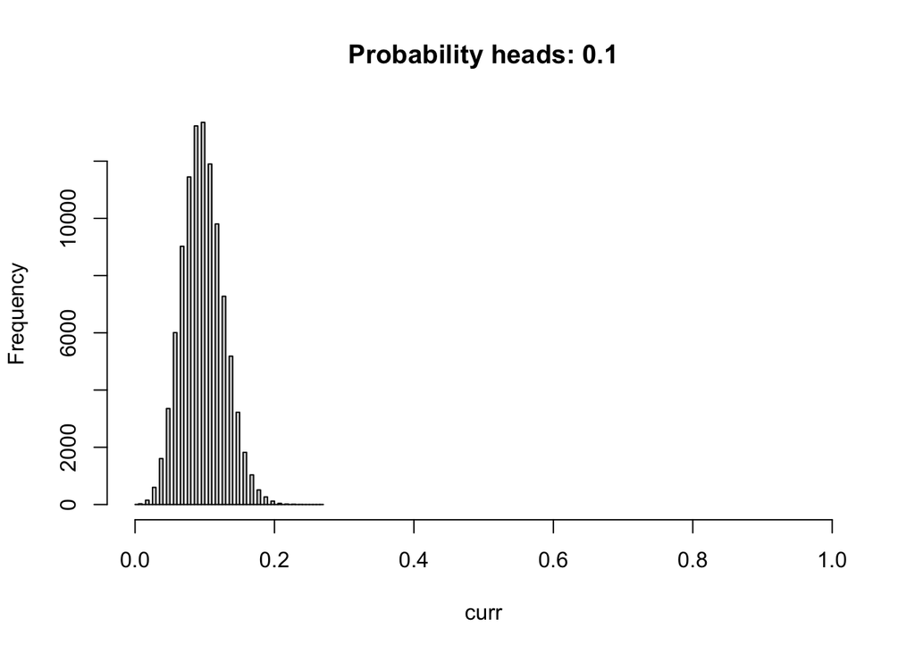

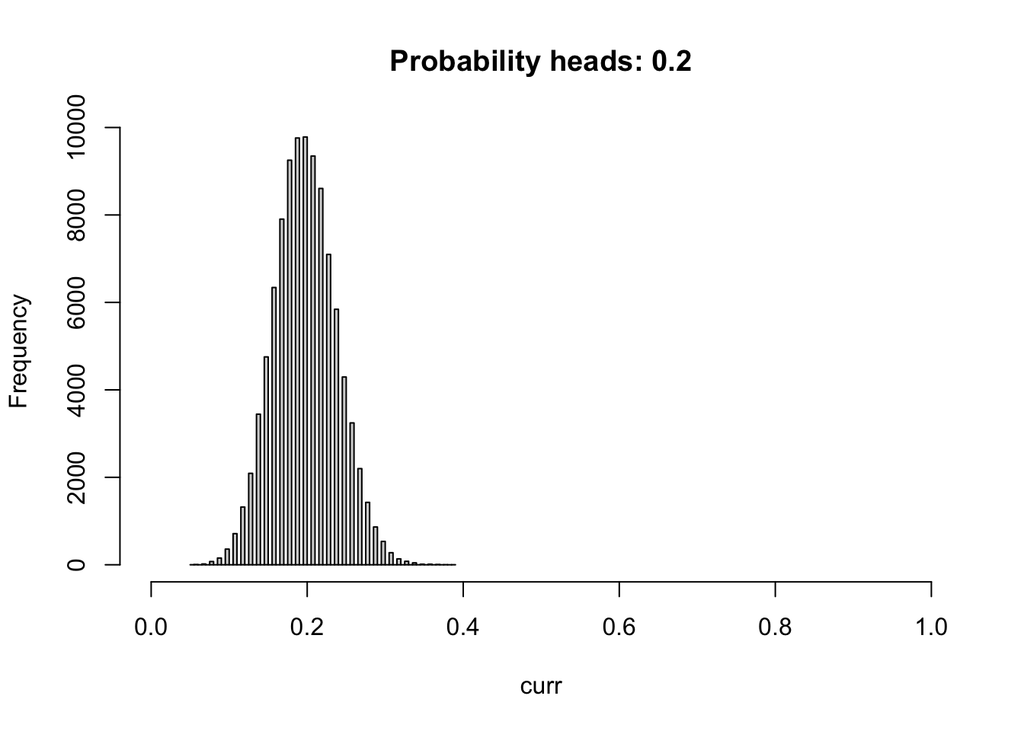

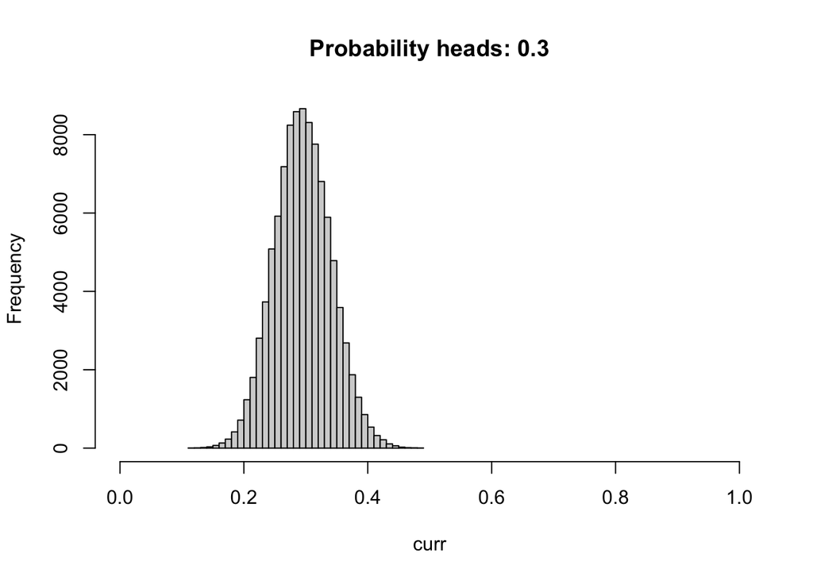

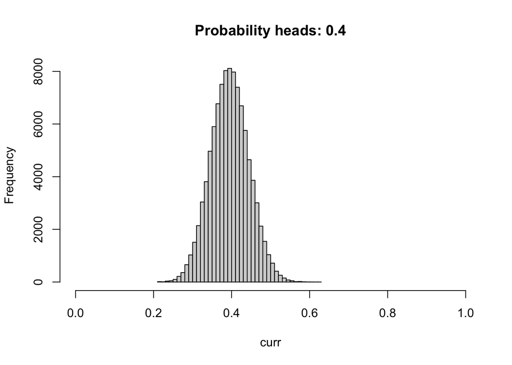

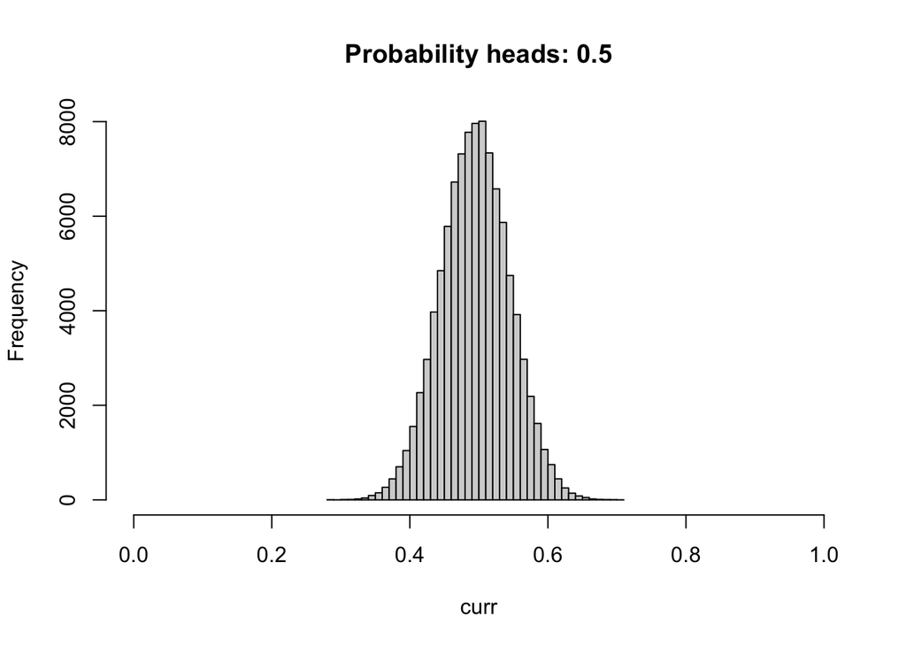

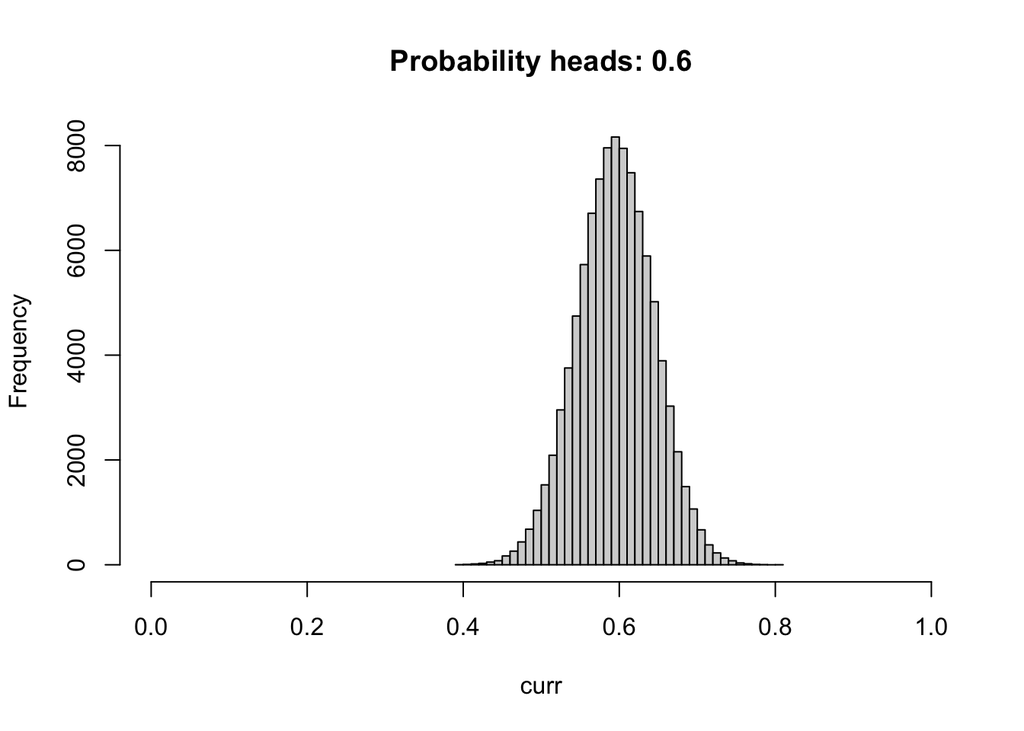

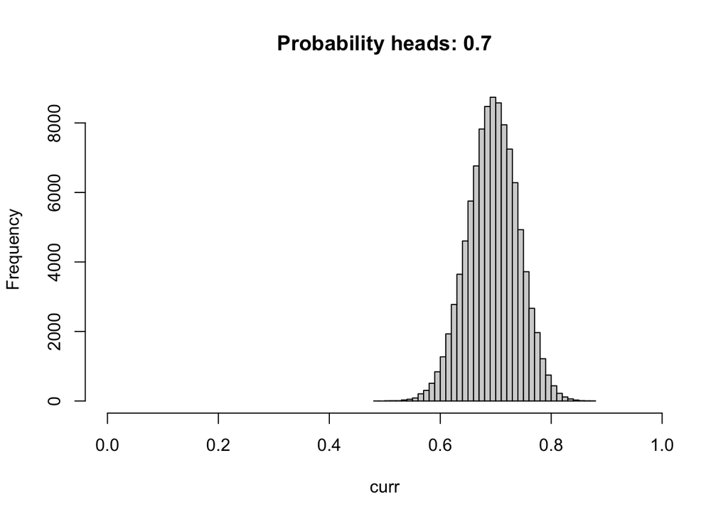

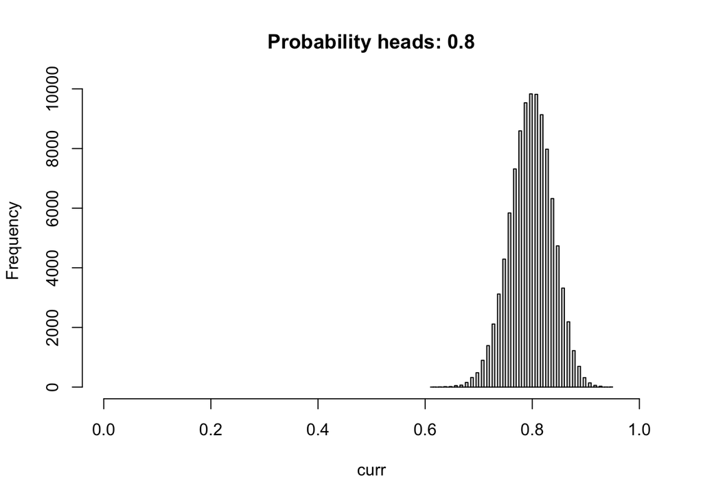

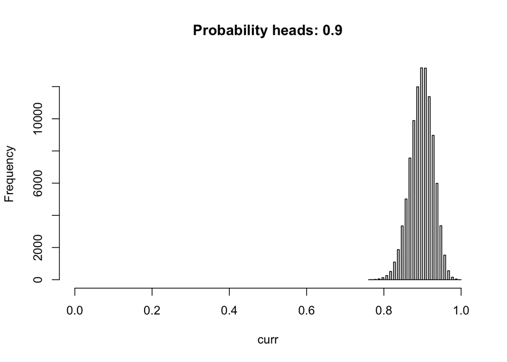

```r
n_sessions <- 100000

flip_list <- lapply(heads_probs, function(i) {
    num_heads <- lapply(seq(n_sessions), function(j) {
        result <-
            sample(
                x = c(0, 1),
                size = 100,
                replace = TRUE,
                prob = c(1 - i, i)
            )
        result <- sum(result) / length(result)
        return(result)
    }) %>% unlist()
})
names(flip_list) <- heads_probs

invisible(lapply(names(flip_list), function(i) {
    curr <- flip_list[[i]]
    hist(curr, breaks = 50, xlim = c(0, 1), main = paste("Probability heads:", i))
}))
```